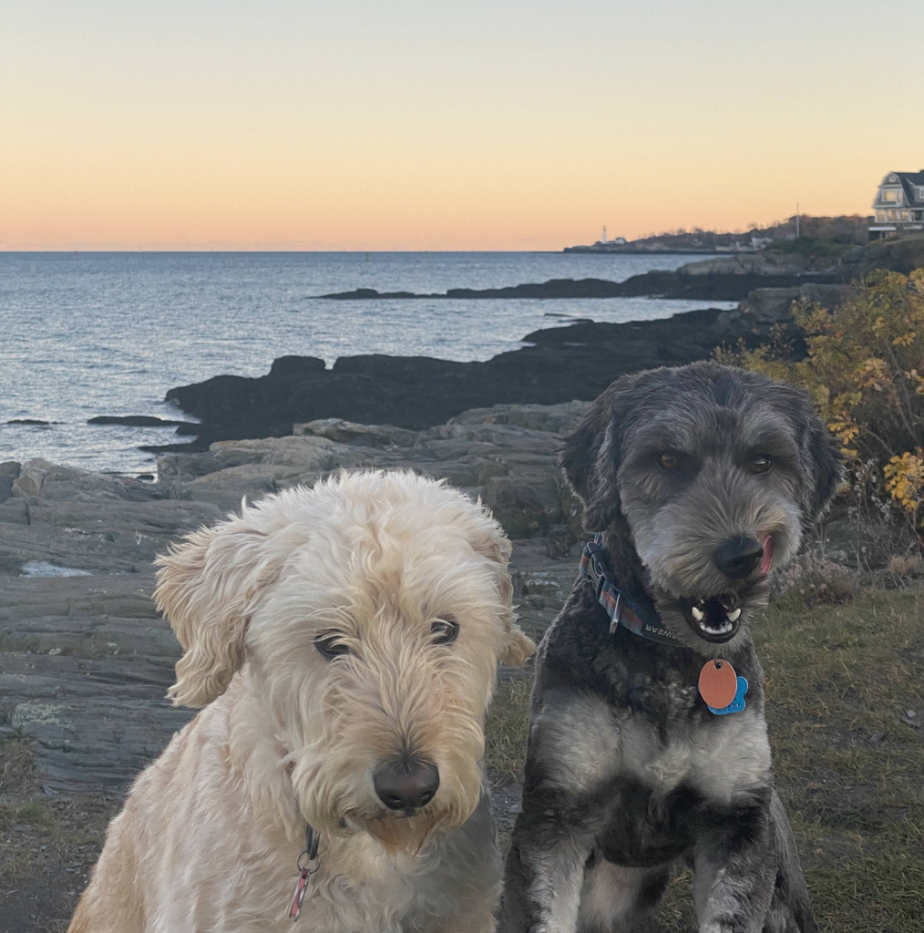

# Murphy Instructions

## Food - Morning

- 1 scoop dry food
- Meds - Morning Pill Box Side (3/4 apoquel, 1 cosequin, 1 trazadone)
- Drizzle about teaspoon to tablespoon of the tuna gel on the meds in his bowl and he’ll eat them

## FOOD - Evening

- 1 scoop dry food
- We usually do 1/2 at 5pm and 1/2 at 7pm but it’s ok to combine at 5pm. He might be a little whiny if you do combine but you can ignore him)
- Meds - Evening Pill Box Side (1 trazadone)
- Drizzle about a teaspoon of the tuna gel on the meds in his bowl and he’ll eat them

## Walks

- We try to do an AM and PM walk because he usually only poops on walks.
- They can be short walks (even just taking him a few houses down on the leash and back to poop)
- He will often decide he wants to go home after he poops - this is fine

## Daytime

- We don’t keep Murphy in a crate at home, and he can be left out during the day when you’re not around. He appreciates being let out to go to the bathroom at least every 6-7 hours.

## Overnight

We let him out to pee before we go to bed. He is (somewhat) trained to go when you say “go potty”. We don’t keep Murphy in a crate at night, he’s allowed to sleep anywhere downstairs.

## Notes

He is very allergic to food with chicken. Please don’t give him Beacon’s food or treats. Even if it says “beef” or “peanut butter” there’s usually chicken by-product in most dog foods. We’ve provided a bag of treats.